# STAT454_final_proj

Yunkun Yang

## Setups

We will use the Califonia Housing data which is provided by SKlearn.[1] The dataset includes the data of houses and some general information about certain district (given by longitutde and latitude). There are a few columns in the dataset, longitute, latitude, housingMedianAge, total rooms, total bedrooms, populations, number of households, median income and median house value of the district. The dataset contains 20639 rows and 9 variables. We will consider each district as one record, hence we can ignore the longitute and latitude variables.

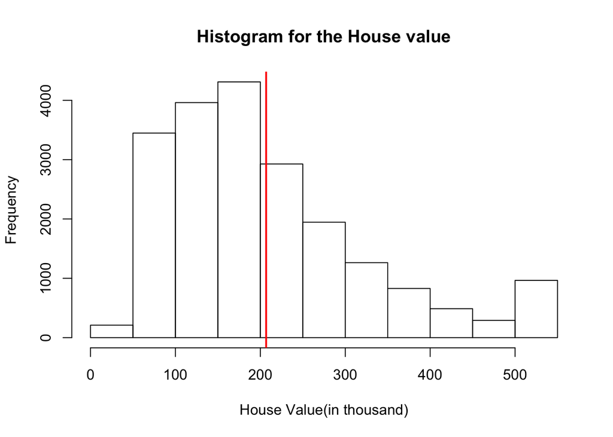

We will first plot the histogram of the House value so we are able to see the general trend of the response variable. The red stright line indicates the population mean. The shape is not a typical bell-shaped trend, and it contains some outliers over 500k.

```
##
## Call:
## lm(formula = log(HouseValue) ~ ., data = population)
##
## Residuals:
##     Min      1Q  Median      3Q     Max
## -2.9270 -0.2322  0.0197  0.2454  2.7759
##
## Coefficients:
##                    Estimate Std. Error t value Pr(>|t|)
## (Intercept)       1.089e+01  1.166e-02  933.88   <2e-16 ***
## housingMedianAge  7.942e-03  2.358e-04   33.69   <2e-16 ***
## totalRooms       -1.090e-04  4.335e-06  -25.14   <2e-16 ***
## totalBedrooms     4.123e-04  3.896e-05   10.58   <2e-16 ***
## population       -1.490e-04  6.061e-06  -24.58   <2e-16 ***
## households        7.380e-04  4.190e-05   17.61   <2e-16 ***
## Income            2.275e-01  1.781e-03  127.78   <2e-16 ***
## ---
## Signif. codes:  0 '***' 0.001 '**' 0.01 '*' 0.05 '.' 0.1 ' ' 1
##
## Residual standard error: 0.3952 on 20632 degrees of freedom
## Multiple R-squared:  0.5178, Adjusted R-squared:  0.5177
## F-statistic:  3693 on 6 and 20632 DF,  p-value: < 2.2e-16
```

For our better understanding, a linear model can be constructed on the entire dataset and all variables are quite siginificant to the housing value.

## Imputation

We will use 6 methods of imputation as mentioned above, complete case, mean imputation, random hot deck imputation, simple regression imputation, random regression imputation and knn imputation (in this case we choose k = 10 so it won’t be too computationally complex but still capture information from some of the neighbors).

## MCAR Simulation

### MCAR with 1 run each

```
## [1] "Start Simulation (1 run each)"
```

```
## [1] "Finished SRSWOR with samplesize = 500 with the missing prob 0.6"
## [1] "Finished SRSWOR with samplesize = 1000 with the missing prob 0.6"
## [1] "Finished SRSWOR with samplesize = 2000 with the missing prob 0.6"
## [1] "Finished SRSWOR with samplesize = 500 with the missing prob 0.75"
## [1] "Finished SRSWOR with samplesize = 1000 with the missing prob 0.75"
## [1] "Finished SRSWOR with samplesize = 2000 with the missing prob 0.75"
## [1] "Finished SRSWOR with samplesize = 500 with the missing prob 0.8"
## [1] "Finished SRSWOR with samplesize = 1000 with the missing prob 0.8"
## [1] "Finished SRSWOR with samplesize = 2000 with the missing prob 0.8"
```

```
## [1] "Simulation Ends"
```

```
## [1] "With the simulation of one run for each setting, it may be distorted by some of the outliers"
```

|  | NoNAs | Complete | Mean | Hot_deck | Regression | RegrRandResid | knn10 |
| --- | --- | --- | --- | --- | --- | --- | --- |
| samplesize = 500, (0.6) | 212 | 202746.6 | 202746.6 | 208346.6 | 204654.7 | 205624.1 | 199420.3 |
| samplesize = 1000, (0.6) | 408 | 214045.7 | 214045.7 | 218008.7 | 214760.6 | 215993.9 | 210475.4 |
| samplesize = 2000, (0.6) | 775 | 213251.7 | 213251.7 | 213651.0 | 213088.2 | 212400.3 | 210533.5 |
| samplesize = 500, (0.75) | 125 | 200383.2 | 200383.2 | 199778.0 | 203973.5 | 203528.4 | 200137.2 |
| samplesize = 1000, (0.75) | 255 | 209349.0 | 209349.0 | 211343.2 | 210471.4 | 210277.8 | 208294.5 |
| samplesize = 2000, (0.75) | 501 | 207887.3 | 207887.3 | 206869.3 | 208978.2 | 208800.5 | 206268.9 |
| samplesize = 500, (0.8) | 105 | 206225.9 | 206225.9 | 203258.4 | 202691.2 | 204793.3 | 202644.3 |
| samplesize = 1000, (0.8) | 195 | 204363.9 | 204363.9 | 200948.4 | 204856.3 | 204253.9 | 203142.2 |
| samplesize = 2000, (0.8) | 394 | 206602.0 | 206602.0 | 205185.8 | 206371.4 | 205757.7 | 205490.0 |

### MCAR with 100 run each

```
## [1] "Start Simulation (100 run each)"
```

```
## [1] "Finished SRSWOR with samplesize = 500 with the missing prob 0.6"
## [1] "Finished SRSWOR with samplesize = 1000 with the missing prob 0.6"
## [1] "Finished SRSWOR with samplesize = 2000 with the missing prob 0.6"
## [1] "Finished SRSWOR with samplesize = 500 with the missing prob 0.75"
## [1] "Finished SRSWOR with samplesize = 1000 with the missing prob 0.75"
## [1] "Finished SRSWOR with samplesize = 2000 with the missing prob 0.75"
## [1] "Finished SRSWOR with samplesize = 500 with the missing prob 0.8"
## [1] "Finished SRSWOR with samplesize = 1000 with the missing prob 0.8"
## [1] "Finished SRSWOR with samplesize = 2000 with the missing prob 0.8"
```

```
## [1] "Simulation Ends"
```

|  | NoNAs | Complete | Mean | Hot_deck | Regression | RegrRandResid | knn10 |
| --- | --- | --- | --- | --- | --- | --- | --- |
| samplesize = 500, (0.6) | 199.30 | 208823.8 | 208823.8 | 209234.5 | 207848.3 | 207844.5 | 204989.2 |
| samplesize = 1000, (0.6) | 400.53 | 207855.5 | 207855.5 | 207324.4 | 206570.9 | 206419.9 | 204116.7 |
| samplesize = 2000, (0.6) | 803.36 | 208091.2 | 208091.2 | 208008.8 | 207318.7 | 207318.2 | 205128.7 |
| samplesize = 500, (0.75) | 125.78 | 206150.1 | 206150.1 | 206370.1 | 206559.9 | 206517.9 | 204584.5 |
| samplesize = 1000, (0.75) | 250.17 | 206574.2 | 206574.2 | 206522.9 | 206840.4 | 206932.4 | 205218.7 |
| samplesize = 2000, (0.75) | 500.34 | 206398.1 | 206398.1 | 206319.2 | 206936.1 | 206974.3 | 205495.9 |
| samplesize = 500, (0.8) | 100.03 | 206000.7 | 206000.7 | 205961.3 | 206306.3 | 206196.2 | 204864.0 |
| samplesize = 1000, (0.8) | 199.66 | 206414.0 | 206414.0 | 206284.3 | 206829.9 | 206931.1 | 205517.6 |
| samplesize = 2000, (0.8) | 398.25 | 206648.2 | 206648.2 | 206606.3 | 206786.9 | 206771.0 | 205633.8 |

```
##                            Complete      Mean  Hot_deck  Regression
## samplesize = 500, (0.6)   1979.8937 1979.8937 2390.5725 1004.419433
## samplesize = 1000, (0.6)  1011.5655 1011.5655  480.5373  272.969516
## samplesize = 2000, (0.6)  1247.2963 1247.2963 1164.9250  474.772780
## samplesize = 500, (0.75)   693.8144  693.8144  473.8240  284.038890
## samplesize = 1000, (0.75)  269.6700  269.6700  321.0425    3.462761
## samplesize = 2000, (0.75)  445.8427  445.8427  524.6928   92.188760
## samplesize = 500, (0.8)    843.1837  843.1837  882.6488  537.570220
## samplesize = 1000, (0.8)   429.9093  429.9093  559.6126   13.963917
## samplesize = 2000, (0.8)   195.6904  195.6904  237.5867   56.989980
##                           RegrRandResid    knn10
## samplesize = 500, (0.6)      1000.59031 1854.703
## samplesize = 1000, (0.6)      423.99463 2727.163
## samplesize = 2000, (0.6)      474.24933 1715.176
## samplesize = 500, (0.75)      326.05372 2259.367
## samplesize = 1000, (0.75)      88.51740 1625.163
## samplesize = 2000, (0.75)     130.43655 1347.980
## samplesize = 500, (0.8)       647.74104 1979.914
## samplesize = 1000, (0.8)       87.19798 1326.320
## samplesize = 2000, (0.8)       72.91539 1210.155
```

After run the simulation 100 times for the same settings, we have 100 means for different imputation methods. By CLT, they should all have the mean $\mu$ of the population. Because there are a few extreme values in the original distribution, by taking multiple runs, the effect of the extreme values cannot be erased, but somehow buffered.

We present the second table and calculate the difference between the average of those means and the population mean. We can see that regression imputations outrun other imputation methods. One of the reason that Mean imputation and Random Hot Deck imputation do not work in this case can be that they cannot ignore the effect of the outliers. The regression works well because the original values in the population can be modelled using proper regression model as we discussed in the previous section.

## MAR simulation with 1 run

```
## [1] "Start Simulation (1 run each)"
```

```
## [1] "Finished SRSWOR with samplesize = 500 with the missing prob 0.81"
## [1] "Finished SRSWOR with samplesize = 1000 with the missing prob 0.81"
## [1] "Finished SRSWOR with samplesize = 2000 with the missing prob 0.81"
```

```
## [1] "Simulation Ends"
```

|  | NoNAs | Complete | Mean | Hot_deck | Regression | RegrRandResid | knn10 |
| --- | --- | --- | --- | --- | --- | --- | --- |
| samplesize = 500, (0.81) | 99 | 211629.0 | 211629.0 | 214764.5 | 211525.1 | 211545.7 | 209775.9 |
| samplesize = 1000, (0.81) | 192 | 209916.4 | 209916.4 | 210101.3 | 208927.0 | 209458.2 | 207739.3 |
| samplesize = 2000, (0.81) | 408 | 210666.8 | 210666.8 | 210062.5 | 210855.2 | 209771.0 | 209514.7 |

```
##                           Complete     Mean Hot_deck Regression
## samplesize = 500, (0.81)  4785.075 4785.075 7920.558   4681.196
## samplesize = 1000, (0.81) 3072.474 3072.474 3257.436   2083.128
## samplesize = 2000, (0.81) 3822.906 3822.906 3218.582   4011.282
##                           RegrRandResid     knn10
## samplesize = 500, (0.81)       4701.834 2931.9848
## samplesize = 1000, (0.81)      2614.328  895.3526
## samplesize = 2000, (0.81)      2927.102 2670.7949
```

We noticed that compared to MCAR, under MAR mechnism, the imputed values did not contribute too much, and the difference between the calculated mean and population mean is much bigger. To work with MAR mechnism, more advanced imputation methods are required or a different techniques can better work.